# Predictive Fishing part 2 - Data Wrangling

Sun 04 February 2018

In this notebook, we clean / transform our data. We learn how to use Regular Expressions, Levenschtein distance and other pandas cleaning techniques.

**Results**  
Our data is clean and ready to be ingested into SQL.

**Limitations**

- Historical weather conditions missing for some trips
- Safety rating and catch rating missing for most trips
- Hidden variables. We recognise that there will always be hidden variables in fishing.

**Click the button below if you want to see the code**

```python
from IPython.display import HTML
HTML('''
''')
```

# Extract Data from Google Sheets

In [Part 1](https://jasonwillschiu.github.io/blog/2018-01-11-FishingPart1/), I go into more depth on how to do this.

Start with loading libraries we need.

```python
# Put us in the right folder that contains our client_secret.json file
import os
os.chdir('C:\\Users\\JWC\\Google Drive\\Home\\Datastuff\\homepro\\Fishing')

from oauth2client.service_account import ServiceAccountCredentials
import pygsheets
import pandas as pd
import numpy as np
import re
import ipy_table as tbl # for tables

# Visuals
import matplotlib.pyplot as plt
import seaborn as sns
import ezhc as hc
%matplotlib inline
from IPython.display import Image

# Check what was loaded
%load_ext version_information
%version_information pandas, ipython, jupyter, ezhc, pygsheets, oauth2client
```

| Software | Version |
| --- | --- |
| Python | 3.6.1 64bit [MSC v.1900 64 bit (AMD64)] |
| IPython | 6.2.1 |
| OS | Windows 10 10.0.16299 SP0 |
| pandas | 0.22.0 |
| ipython | 6.2.1 |
| jupyter | 1.0.0 |
| ezhc | 0.7.1 |
| pygsheets | 1.1.3 |
| oauth2client | 4.1.2 |
| Sun Feb 04 00:13:15 2018 AUS Eastern Daylight Time |  |

Authorisation for Google Sheets and extracting our data into two dataframes.

```python
# The authorisation part of accessing google sheets
scope = ['https://spreadsheets.google.com/feeds',
        'https://www.googleapis.com/auth/drive']
creds = ServiceAccountCredentials.from_json_keyfile_name('client_secret.json', scope)
client = pygsheets.authorize(credentials=creds)

# Open a workbook by name
# Open a wooksheet by name
sheet1 = client.open("Fishing Spots").worksheet_by_title('Journalv3')
sheet2 = client.open("Fishing Spots").worksheet_by_title('Journalv2')

# Get all values outputs a list of lists, easier to handle than list of dicts
jv3 = sheet1.get_as_df()
jv2 = sheet2.get_as_df()
```

Have a quick browse of the state of both our datasets.

Journalv3. Currently date, spot, year, month and day are cleaned.

```python
jv3.head()
```

|  | Date | Spot | Baits/Lures | Fish Caught | Water Temp | Swell | Wind | Time fished | In what tide | Moon phase | Rain | Sun / Cloud | Year | Month | Day |
| --- | --- | --- | --- | --- | --- | --- | --- | --- | --- | --- | --- | --- | --- | --- | --- |
| 0 | 2010-09-09 | North Whale | Metals | 1x bonito |  | 2.3m | small SW | 5:30am - 8:30am | 7:40am high |  | None | Sunny | 2010 | 9 | 9 |
| 1 | 2010-09-09 | North Whale | Zipbaits System Minnow 15HD | 1x salmon |  | 2.3m | small SW | 5:30am - 8:30am | 7:40am high |  | None | Sunny | 2010 | 9 | 9 |
| 2 | 2010-04-08 | North Whale | Metals | 1x squid |  | 1.2m | small W | 6 - 8 am | 9:30am low |  | None | Sunny | 2010 | 4 | 8 |
| 3 | 2010-04-08 | North Whale | Metals | 1x bonito |  | 1.2m | small W | 6 - 8 am | 9:30am low |  | None | Sunny | 2010 | 4 | 8 |
| 4 | 2010-04-08 | North Whale | Jackall TN70 | 1x snapper |  | 1.2m | small W | 6 - 8 am | 9:30am low |  | None | Sunny | 2010 | 4 | 8 |

Journalv2. Nothing cleaned yet, but many columns can be used in their current state.

```python
jv2.head()
```

|  | Date | Safety Rating | Catch Rating | Reporter | Spot | Suburb | Fish Species | Qty | Largest Length (cm) | Baits/Lures | ... | Start Tide Height | End Tide Height | Wind Speed (Avg km/h) | Wind Direction | Time Start | Time End | Moon (% full) | Rain | Sun/Cloud | Comments |
| --- | --- | --- | --- | --- | --- | --- | --- | --- | --- | --- | --- | --- | --- | --- | --- | --- | --- | --- | --- | --- | --- |
| 0 | 30 Apr 2017 | 4 | 4 | Jas and Scott | South Bondi | Bondi Beach | Squid | 1 | 25 | Yama Qlive 3.5 Pink | ... | 0.30 | 1.08 | 15.0 | SSW | 5:30 AM | 9:00 AM | 22 | no | Cloudy | Low spot for squid, middle spot for fish |
| 1 | 30 Apr 2017 | 4 | 4 | Jas and Scott | South Bondi | Bondi Beach | Blackfish | 5 | 35 | Cabbage | ... | 0.30 | 1.08 | 15.0 | SSW | 5:30 AM | 9:00 AM | 22 | no | Cloudy | Low spot for squid, middle spot for fish |
| 2 | 30 Apr 2017 | 4 | 4 | Jas and Scott | South Bondi | Bondi Beach | Wrasse | 1 | 30 | Cuttlefish | ... | 0.30 | 1.08 | 15.0 | SSW | 5:30 AM | 9:00 AM | 22 | no | Cloudy | Low spot for squid, middle spot for fish |
| 3 | 30 Apr 2017 | 4 | 4 | Jas and Scott | South Bondi | Bondi Beach | Bream | 2 | 35 | Prawns, Cuttlefish | ... | 0.30 | 1.08 | 15.0 | SSW | 5:30 AM | 9:00 AM | 22 | no | Cloudy | Low spot for squid, middle spot for fish |
| 4 | 1 May 2017 | 4 | 4 | Tim | The Trap | Little Bay | Squid | 3 | 35 | Squid Jig | ... | 0.37 | 0.81 | 10.0 | W | 5:30 AM | 9:00 AM | 32 | no | Sunny | Tim's report |

5 rows × 26 columns

# Transform Data

## Objectives

To have all cells ready to import into SQL (part 3). In this notebook we'll transform our data in the first normal form (1NF), which is defined as: only a single value in each cell and no duplicate rows.

1. Clean jv3 rows:
   - **baits/lures.** Define unique groups. Baits to include: prawns, squid, bread, etc. Lures to include: metal jigs, soft plastics, squid jigs, etc.
   - **fish caught.** Split into species, qty and max size
   - **water temp.** Remove °C symbol
   - **swell.** Split into magnitude, direction and period
   - **wind.** Split into magnitude and direction
   - **time fished.** Change into morning and afternoon. I don't like fishing at night, but in future will allow night as a variable
   - **in what tide.** Split into start tide height, end tide height, max/min tide and incoming/outgoing
   - **moon phase.** Remove % sign
   - **rain.** Change into rain_when. Which will be today's perspective from the last or future rain. Options will be 2,1,0,-1,-2. Where 0 is raining today, 2 means it rained 2 or 2+ days ago and -1 means it rains 1 day from now.
   - **sun/cloud.** Replace with light_level. Will use the following key: sunny = 2, cloudy = 1, night = 0.
2. Create useful columns
   - **bait_type.** Groups for different baits and lures
   - **bustoff?** Yes or no if a fish was hooked but got away
3. Add useful rows to jv3 from jv2.
   - **safety rating.**
   - **catch rating.**
   - **suburb.** This will be used to later plot spots on a map with latitude and longitude.
4. Combine jv3 and jv2 so we have one clean dataset

## Safety Rating

This is my own safety rating system.  
5 = No swell touching feet  
4 = Swell touches feet now and then  
3 = Swell knee high now and then  
2 = Swell above knee high now and then. Don't fish  
1 = Swell could easily knock you over. Don't fish

## Catch Rating

This is my own catch rating system.  
5 = Firing day, large quality/quantity of target species caught  
4 = somewhere inbetween  
3 = I enjoyed myself but nothing to write home about  
2 = somewhere inbetween  
1 = No one catches a thing

## Machine Learning possibilities

### Safety Rating

If we knew the height above sea level and direction that each rock ledge faced we probably wouldn't need machine learning. However since we don't have that information we may be able to imply the correct safety.

Possible algorithms: linear regression, others.

```
safety rating = function(swell direction, swell period, swell magnitude, spot, tide height)
```

### Catch Rating

This will be more subjective than safety.

Possible algorithms: linear regression, others.

```
catch rating = function(fish species, fish qty, fish size max)
```

### Bait Type

Possible algorithms: linear regression, others.

```
catch rating = function(fish species, fish qty, fish size max)
```

## Regular Expressions (Regex)

In this portion of the notebook I mostly use regular expressions to clean, which makes short work of most of the cleaning tasks. I will explain a little how my regular expressions are created as they are pretty hard to decipher if you don't use them often. Try these links to [learn](https://regexone.com/lesson/introduction_abcs) and [test](https://regex101.com/) regex.

```python
# Make all column names lower case
jv3.columns = jv3.columns.str.lower()

# Remove spaces and special characters from columns
jv3['baits_lures'] = jv3['baits/lures'].str.lower()
jv3['spot'] = jv3['spot'].str.lower()

# Remove °C from water temp and remove space
jv3['water_temp'] = jv3['water temp'].str.replace('°C','')
jv3['water_temp'] = pd.to_numeric(jv3['water_temp'],errors='coerce')

# Extract the number before 'm' for swell magnitude
jv3['swell_magnitude'] = jv3['swell'].str.extract('^(.*?)m',expand=False)
jv3['swell_magnitude'] = pd.to_numeric(jv3['swell_magnitude'],errors='coerce')
# Extract any combination of North South West East. Requires ()
jv3['swell_direction'] = jv3['swell'].str.extract('([NSWE]+)',expand=False)
# Extract the number between the digit and s, including digit
jv3['swell_period'] = jv3['swell'].str.extract(' (\d.*?)s',expand=False)

# Extract the number before 'k' for wind magnitude
jv3['wind_magnitude'] = jv3['wind'].str.extract('^(.*?)k',expand=False)
# Extract any combination of North South West East. Requires ()
jv3['wind_direction'] = jv3['wind'].str.extract('([NSWE]+)',expand=False)

# Extract the number before '%" for moon phase and remove space
jv3['moon_phase_percent_full'] = jv3['moon phase'].str.extract('^(.*?)%',expand=False)
jv3['moon_phase_percent_full'] = pd.to_numeric(jv3['moon_phase_percent_full'],errors='coerce',downcast='integer');

# Extract the number before 'x' for fish caught
jv3['fish_qty'] = jv3['fish caught'].str.extract('^(.*?)x',expand=False)
jv3['fish_qty'] = pd.to_numeric(jv3['fish_qty'].fillna(0),errors='coerce')

# Extract the number before 'cm' for size of fish caught in cm
jv3['fish_size_max'] = jv3['fish caught'].str.extract('(\d+)cm',expand=False)
jv3['fish_size_max'] = jv3['fish_size_max'];

# Extract the string after 'x' for species of fish caught
jv3['fish_species'] = jv3['fish caught'].str.extract('x(.*?)$',expand=False)
# Replace NaN values with 'none'
jv3['fish_species'] = jv3['fish_species'].astype(object).fillna('-')
# make all lowercase and strip white spaces
jv3['fish_species'] = jv3['fish_species'].str.lower()
jv3['fish_species'] = jv3['fish_species'].str.strip()

# change all times to either am or pm, then rename to morning and afternoon
jv3['time'] = np.where(jv3['time fished'].str.contains('am'),'morning','afternoon')

# rain info
jv3['rain_when'] = np.where(jv3['rain'].str.contains('yes',case=False),0,2)

# light level info
jv3['light_level'] = np.where(jv3['sun / cloud'].str.contains('cloud',case=False),1,2)

# tide info
jv3['min_tide'] = jv3['in what tide'].str.extract(' (\d.*?)-',expand=False)
jv3['max_tide'] = jv3['in what tide'].str.extract('-(\d.+)$',expand=False)
jv3['min_tide'] = jv3['min_tide'].str.replace('m','')
jv3['max_tide'] = jv3['max_tide'].str.replace('m','')
jv3['tide_direction'] = jv3['in what tide'].str.lower().str.extract('^(out|in)',expand=False)
jv3['tide_direction'] = jv3['tide_direction'].str.replace('in','incoming')
jv3['tide_direction'] = jv3['tide_direction'].str.replace('out','outgoing')
# another way of doing if, else in pandas
# use .loc[if statement,[affects this col]] = then this result
jv3.loc[jv3['in what tide'].str.contains('high',case=False),['tide_direction']] = 'incoming'
jv3.loc[jv3['in what tide'].str.contains('low',case=False),['tide_direction']] = 'outgoing'
```

### Regex: Capture everything between two characters

In Python, regex is always between quotes ''.  
One commonly used expression is capturing between two characters like so.  
Here we capture everything between 'a' and 'b'.

```
regex
'a(.*?)b'

a = border character, can be anything
() = capture everything enclosed
. = any single character
*? = Matches between zero and unlimited times, as few times as possible, expanding as needed (lazy)
b = border character, can be anything
```

### Regex: Capture any combination of these letters

The below captures any combination of letters containing N(orth) S(outh) E(ast) W(est).  
Directions on a map can range from single letter N (North)  
Two letters SE (South East)  
Three letters ESE (East South East).

```
regex
'([NSWE]+)'

() = capture everything enclosed
[] = single characters of everything inside
NSWE = characters to match
+ = one or more characters
```

### Regex: Capture literal one or the other

The below captures the first instance of out or in. Some lines contain both out and in so I want only the first match.

```
regex
'^(out|in)'

^ = start of the line
() = capture everything enclosed
out|in = out 'or' in
```

Observing our cleaned data we see all columns are cleaned except for baits_lures. Which we will clean with a different method.

```python
jv3[['date','time','spot','baits_lures','fish_qty',
     'fish_species','fish_size_max','water_temp',
    'swell_magnitude','swell_direction','swell_period',
    'wind_magnitude','wind_direction','moon_phase_percent_full']].sample(5)
```

|  | date | time | spot | baits_lures | fish_qty | fish_species | fish_size_max | water_temp | swell_magnitude | swell_direction | swell_period | wind_magnitude | wind_direction | moon_phase_percent_full |
| --- | --- | --- | --- | --- | --- | --- | --- | --- | --- | --- | --- | --- | --- | --- |
| 19 | 2013-07-20 | afternoon | mahon pool | brown weed | 2 | blackfish | NaN | 17.5 | 1.3 | ENE | 8 | 14 | WNW | 92.0 |
| 308 | 2017-01-26 | morning | dudley beach rocks | prawns | 2 | bream | NaN | 22.7 | 1.1 | SSE | 11 | 16 | SSW | 2.0 |
| 280 | 2016-10-22 | afternoon | north bondi | probably prawns | 1 | leather jacket | NaN | 18.9 | 1.8 | SSE | 8 | 23 | SSE | 53.0 |
| 174 | 2015-12-30 | morning | bluefish main | garfish | 1 | salmon | NaN | 21.2 | 1.3 | SSE | 8 | 11 | SSW | 75.0 |
| 319 | 2017-02-12 | morning | bluefish main | garfish | 0 | - | NaN | 22.7 | 1.3 | ENE | 9 | 10 | NE | 97.0 |

# Pattern Matching using Levenschtein Distance

In the above cleaning we use regex to capture patterns and use if-else conditional statements to map inconsistent data to a consistent version. This solves a lot of our cleaning issues, but not all.

We have some columns (baits_lures and fish_species) that are categorical with many categories. We would like to standardise the fish_species column so a fish species is a unique identifier (i.e. kingfish are commonly called kingies, kingy or king). We would also like to create a bait_type column where we classify what bait or lure is used, for example cabbage weed, string weed and bubble weed can be classified as seaweed. We won't make baits and lures into unique identifiers as there are just too many different combinations.

With both standardising and classifying without any labels, we can imply our desired result from our current data. For instance kingfish and common aliases kingies, kingy and king all contain the substring 'king'. My original solution was based purely on substrings before discovering [Levenshtein distance](https://en.wikipedia.org/wiki/Levenshtein_distance).

Levenschtein Distance between two words is the minimum number of changes (insertions, deletions or substitutions) required to turn one word into the other. We can use it to measure how closely related two strings are. This way we'll have an advantage over purely using substrings which will be a binary result (True or False).

I've chosen this algorithm because it is relatively simple to understand and runs quickly. Other algorithms we could look into are:

- [Hamming distance](https://en.wikipedia.org/wiki/Hamming_distance)
- [Damerau–Levenshtein distance](https://en.wikipedia.org/wiki/Damerau%E2%80%93Levenshtein_distance)
- [Jaro–Winkler distance](https://en.wikipedia.org/wiki/Jaro%E2%80%93Winkler_distance)
- [Gestalt approach](https://collaboration.cmc.ec.gc.ca/science/rpn/biblio/ddj/Website/articles/DDJ/1988/8807/8807c/8807c.htm)

The particular implementation of Levenschtein Distance we are using is the ['fuzzywuzzy'](https://github.com/seatgeek/fuzzywuzzy) library because it can be set to consider substrings.

A quick demonstration of Levenschtein Distance and why I've chosen fuzzywuzzy.

```python
import Levenshtein
from fuzzywuzzy import fuzz
import fuzzywuzzy
```

A perfect match, 'prawn' and 'prawn'. The same word

```python
Levenshtein.ratio('prawn','prawn')
```

```
1.0
```

Here we compare 'prawn' with 'prawns'. The Levenschtein ratio is ~0.91

```python
Levenshtein.ratio('prawns','prawn')
```

```
0.9090909090909091
```

Comparing 'peeled endeavor prawns' with 'prawn' yields a ratio of ~0.37

```python
Levenshtein.ratio('peeled endeavor prawns','prawn')
```

```
0.37037037037037035
```

Comparing 'bread' with 'prawn' yields a ratio of 0.4. Clearly bread should rate lower than peeled endeavor prawns. However knowing how the Levenschtein algorithm works it makes sense that bread is rated higher, since there were more edits required to change peeled endearvor prawns into prawn than to change bread into prawn.

```python
Levenshtein.ratio('bread','prawn')
```

```
0.4
```

Hence we use Fuzzywuzzy's partial_ratio method, which checks if one string is a substring of the other. One thing to note is fuzzywuzzy multiplies ratios by 100.

Comparing 'peeled endeavor prawns' with 'prawn' yields a ratio of 100. A perfect match because prawn is a substring in peeled endeavor prawns.

```python
fuzz.partial_ratio('peeled endeavor prawns','prawn')
```

```
100
```

Comparing 'bread' with 'prawn' yields a ratio of 40, which is equivalent to a Levenschtein ratio of 0.4.

```python
fuzz.partial_ratio('bread','prawn')
```

```
40
```

Below we compare 'prawns' to our baits_lures using partial_ratio and the Levenschtein library. We find partial_ratio with a better result overall.

```python
baits = list(jv3['baits_lures'].str.lower().unique())
fuz = []
lev = []
tester = 'prawns'
for item in baits:
    fuz.append([item,fuzz.partial_ratio(item,tester)])
    lev.append([item,Levenshtein.ratio(item,tester)])

df_fuz = pd.DataFrame(fuz,columns=['baits_lures','partial_ratio'])
df_lev = pd.DataFrame(lev,columns=['baits_lures','leven_ratio'])
pd.merge(df_fuz,df_lev,how='inner',on='baits_lures').sort_values(by=['partial_ratio','leven_ratio'],ascending=False).head(18)
```

|  | baits_lures | partial_ratio | leven_ratio |
| --- | --- | --- | --- |
| 40 | prawns | 100 | 1.000000 |
| 20 | prawn | 100 | 0.909091 |
| 62 | good prawns | 100 | 0.705882 |
| 18 | banana prawns | 100 | 0.631579 |
| 98 | probably prawns | 100 | 0.571429 |
| 102 | prawns and squid | 100 | 0.545455 |
| 103 | prawns and bread | 100 | 0.545455 |
| 87 | fresh prawns/squid | 100 | 0.500000 |
| 73 | coles banana prawns | 100 | 0.480000 |
| 108 | prawns and all sorts | 100 | 0.461538 |
| 48 | peeled endeavor prawns | 100 | 0.428571 |
| 104 | probably prawns and bread | 100 | 0.387097 |
| 63 | windybanks hawksbury prawns | 100 | 0.363636 |
| 33 | squid/prawn | 91 | 0.588235 |
| 113 | prawn light and net | 83 | 0.400000 |
| 6 | gars | 50 | 0.400000 |
| 12 | brown weed | 50 | 0.375000 |
| 91 | squid wings | 50 | 0.352941 |

Now we create a function to rate our data against a corpus of good words. We aren't expecting an amazing result, but it will help a lot. Since we don't have labels, we won't be able to measure how much it helped until we finish.

```python
def fuzzy_mapper(series,fillers):
    output = []
    rating = {}
    for item in series:
        for fill in fillers:
            # Create rating for all potential fill words
            rating[fuzz.partial_ratio(fill,item)] = fill
        # Append max rated word
        output.append(rating[max(rating)])
        # Reset rating for next item in the series
        rating = {}
    return output
```

```python
bait_classes = ['metal jigs','swimbaits','stickbaits','poppers','squid jigs',
                'soft plastics','bait fish','squid','seaweed','bread','prawns',
                'uncommon','vibes']
fish = ['bonito', 'australian salmon', 'arrow', 'squid', 'silver drummer', 'snapper', 'kingfish',
        'pike', 'tailor', 'blackfish', 'sweep', 'black drummer', 'yellowtail scad',
        'frigate mackerel', 'bream', 'cuttlefish', 'silver trevally',
        'sargent baker', 'mullet', 'hairtail', 'longtail tuna', 'wirrah cod',
        'leather jacket', 'grouper', 'garfish', 'flounder','parrotfish','wrasse',
        '-']
```

```python
jv3['bait_type'] = fuzzy_mapper(jv3['baits_lures'],bait_classes)
jv3['fish_species'] = fuzzy_mapper(jv3['fish_species'],fish)
```

```python
key_cols = ['date','time','spot','baits_lures','bait_type','fish_qty',
     'fish_species','fish_size_max', 'light_level', 'water_temp',
    'swell_magnitude','swell_direction','swell_period',
    'wind_magnitude','wind_direction','moon_phase_percent_full']
```

```python
jv3[key_cols].sample(5,random_state=3)
```

|  | date | time | spot | baits_lures | bait_type | fish_qty | fish_species | fish_size_max | light_level | water_temp | swell_magnitude | swell_direction | swell_period | wind_magnitude | wind_direction | moon_phase_percent_full |
| --- | --- | --- | --- | --- | --- | --- | --- | --- | --- | --- | --- | --- | --- | --- | --- | --- |
| 323 | 2017-03-26 | morning | bond st high rock | prawns | prawns | 3 | black drummer | NaN | 2 | 24.1 | 1.7 | SE | 9 | 6 | WNW | 3.0 |
| 74 | 2014-12-24 | morning | the boot | cabbage weed | seaweed | 5 | blackfish | NaN | 1 | 21.3 | 1.4 | ENE | 7 | 9.3 | SSW | 8.0 |
| 329 | 2017-04-08 | morning | north bondi | samaki rattlesnake ghost 30g | swimbaits | 1 | bonito | NaN | 2 | 24.1 | 1.0 | SE | 7 | 17 | NNW | 97.0 |
| 15 | 2013-07-11 | morning | shelly beach | gars | prawns | 10 | australian salmon | NaN | 1 | 18.3 | 1.5 | SSE | 11 | 4 | W | 9.0 |
| 267 | 2016-09-04 | afternoon | bombo | probably prawns | prawns | 1 | leather jacket | NaN | 2 | 17.5 | 2.4 | S | 10 | 38 | W | 9.0 |

# Another mapper for mapping dictionaries

Above we used Levenschtein distance to imply a bait type using the name of the bait/lure. We will now classify bait types using common words or brands. This function will apply a dictionary for transformations to better capture common brands for lures and aliases for baits.

```python
keyword_to_bait_type = {'yama':'squid jigs','gar':'bait fish','slimy':'bait fish','pil':'bait fish',
                   'cabbage':'seaweed','zman':'soft plastics','squid jig':'squid jigs',
                   'shore jig':'metal jigs','sebile':'swimbaits','yakka':'bait fish',
                       'zip':'swimbaits','samaki':'soft plastics','halco':'metal jigs'}
```

```python
# Takes a dictionary, items in testseries are replaced by values in dictionary if the key is a subset of item
# If not, the original series item is used in the series
def tidy_mapper(testseries,dikt,origseries):
    output = []
    i = 0
    for item in (testseries):
        for key,val in dikt.items():
            if key in item:
                output.append(val)
            else:
                pass
        # if we find no matches use origseries to fill
        i += 1
        if len(output) < i:
            output.append(origseries.iloc[i-1])

    return output
```

```python
jv3['bait_type'] = tidy_mapper(jv3['baits_lures'],keyword_to_bait_type,jv3['bait_type'])
```

We recognise that this mapping still won't be perfect. I will go over the bait_type by hand at the end of this notebook.

Below is a sample of our progress so far.

```python
key_cols = ['date','time','spot','baits_lures','bait_type','fish_qty',
            'fish_species','fish_size_max','water_temp',
            'swell_magnitude','swell_direction','swell_period', 'tide_direction',
            'min_tide', 'max_tide', 'wind_magnitude','wind_direction',
            'moon_phase_percent_full','year','month','day']
```

```python
jv3[key_cols].sample(5)
```

|  | date | time | spot | baits_lures | bait_type | fish_qty | fish_species | fish_size_max | water_temp | swell_magnitude | ... | swell_period | tide_direction | min_tide | max_tide | wind_magnitude | wind_direction | moon_phase_percent_full | year | month | day |
| --- | --- | --- | --- | --- | --- | --- | --- | --- | --- | --- | --- | --- | --- | --- | --- | --- | --- | --- | --- | --- | --- |
| 18 | 2013-07-14 | morning | maroubra beach | string weed | seaweed | 0 | - | NaN | 18.5 | 0.8 | ... | 9.5 | incoming | NaN | NaN | 3.4 | NW | 33.0 | 2013 | 7 | 14 |
| 203 | 2016-04-29 | morning | clovelly cemetary | squid strips (caught fresh) | squid | 1 | bream | NaN | 21.5 | 1.3 | ... | 8 | incoming | 0.6 | 0.7 | 15 | NNE | 57.0 | 2016 | 4 | 29 |
| 101 | 2015-03-08 | morning | killalea | prawns | prawns | 1 | bream | NaN | 22.2 | 1.7 | ... | 11 | incoming | NaN | NaN | 6.2 | SW | 93.0 | 2015 | 3 | 8 |
| 97 | 2015-03-08 | morning | killalea | little metals | metal jigs | 1 | australian salmon | NaN | 22.2 | 1.7 | ... | 11 | incoming | NaN | NaN | 6.2 | SW | 93.0 | 2015 | 3 | 8 |
| 269 | 2016-09-04 | afternoon | bombo | probably prawns | prawns | 0 | - | NaN | 17.5 | 2.4 | ... | 10 | incoming | 0.7 | 1.4 | 38 | W | 9.0 | 2016 | 9 | 4 |

5 rows × 21 columns

# Data back to Google Sheets for cleaning

If you are into fishing, you will know that some bait_type classifications are still wrong, highlighting the importance of domain knowledge in Data Analytics. I will correct these errors in Google Sheets, as manually modifying many individual cells is quicker in spreadsheet than coding.

```python
# Clear the spreadsheet first, in case we end up with a smaller spreadsheet
# The start coordinates are where to start writing in the sheet
# (1,1) is cell (A1), (2,2) will be cell (B2), etc
sheet3 = client.open("Fishing Spots").worksheet_by_title('touchup')
sheet3.clear()
sheet3.set_dataframe(jv3,start=(1,1))
```

After doing manual checks and fixing some cells, here is a sample of the cleaned data.

```python
sheet3 = client.open("Fishing Spots").worksheet_by_title('touchup_v3')
```

```python
j_clean1 = sheet3.get_as_df()
```

```python
j_clean1[key_cols].sample(5)
```

|  | date | time | spot | baits_lures | bait_type | fish_qty | fish_species | fish_size_max | water_temp | swell_magnitude | ... | swell_period | tide_direction | min_tide | max_tide | wind_magnitude | wind_direction | moon_phase_percent_full | year | month | day |
| --- | --- | --- | --- | --- | --- | --- | --- | --- | --- | --- | --- | --- | --- | --- | --- | --- | --- | --- | --- | --- | --- |
| 38 | 2014-05-24 | morning | mahon pool | cabbage weed | seaweed | 0 | - | NaN | 22.4 | 1.0 | ... | 11.8 | outgoing | NaN | NaN | 8.2 | W | 19.0 | 2014 | 5 | 24 |
| 280 | 2016-11-12 | morning | east reef box head | prawns | prawns | 1 | black drummer | 45.0 | 20.6 | 0.9 | ... | 8.0 | incoming | 1.2 | 1.8 | 10.0 | NW | 98.0 | 2016 | 11 | 12 |
| 67 | 2014-11-28 | morning | the boot | squid jig | squid jigs | 1 | calamari | NaN | 20.8 | 1.2 | ... | 9.0 | outgoing | NaN | NaN | 10.0 | S | 33.0 | 2014 | 11 | 28 |
| 184 | 2016-03-14 | night | honeysuckle dr | pillie chunks | bait fish | 20 | hairtail | NaN | 24.4 | 1.3 | ... | 9.0 | incoming | 1.0 | 1.7 | 4.0 | SW | 46.0 | 2016 | 3 | 14 |
| 224 | 2016-08-02 | morning | the boot | whole pillie on ganghooks | bait fish | 1 | tailor | NaN | 18.3 | 1.0 | ... | 10.0 | incoming | 1.2 | 1.4 | 14.0 | WNW | 1.0 | 2016 | 8 | 2 |

5 rows × 21 columns

The next step is to incorporate suburb, catch and safety ratings.

Our corpus of suburbs.

```python
suburb_map = {'whale':'whale beach','clovelly':'clovelly','mahon pool':'maroubra',
             'lurline bay':'maroubra','tomaree':'port stephens','blessings':'maroubra',
             'cremorne':'cremorne','wybung':'wybung','ivo rowe':'coogee',
             'the gutter':'little bay','the boot':'bondi beach','avoca':'avoca beach',
             'blue':'manly','middlehead':'mosman','killalea':'killalea beach',
             'bondi':'bondi beach','shark point':'clovelly','curl':'curl curl beach',
             'janies corner':'forster','hill 60':'port kembla','parsley':'vaucluse',
             'nielsen park':'vaucluse','dover cliff':'dover heights',
             'yellow rock':'malabar','alexa parade':'maroubra',
             'pyrmont':'pyrmont','rose bay':'rose bay','stake':'maroubra',
             'honeysuckle':'newcastle','cronulla':'cronulla','snapper point':'frazer park',
             'trap':'little bay','donkeys':'malabar','bombo':'bombo',
             'la pa':'la perouse','hole in the wall':'avalon',
             'dudley beach':'dudley','redhead':'redhead','bond st':'maroubra',
             'box head':'box head','avalon':'avalon','maroubra':'maroubra',
             'wollumboola lake':'culburra beach','shelly beach':'manly'}
```

```python
# we map v to vaucluse otherwise it will match too many spots
j_clean1['suburb'] = j_clean1['spot']
j_clean1['suburb'] = j_clean1['suburb'].map({'v':'vaucluse'})
j_clean1['suburb'] = tidy_mapper(j_clean1['spot'],suburb_map,j_clean1['suburb'])
```

```python
j_clean1['suburb'].unique()
```

```
array(['whale beach', 'clovelly', 'maroubra', 'manly', 'port stephens',
       'cremorne', 'wybung', 'coogee', 'little bay', 'bondi beach',
       'avoca beach', 'mosman', 'killalea beach', 'curl curl beach',
       'forster', 'port kembla', 'vaucluse', 'dover heights', 'malabar',
       'pyrmont', 'rose bay', 'newcastle', 'cronulla', 'frazer park',
       'bombo', 'la perouse', 'avalon', 'box head', 'culburra beach',
       'dudley', 'redhead'], dtype=object)
```

```python
jv2.head()
```

|  | Date | Safety Rating | Catch Rating | Reporter | Spot | Suburb | Fish Species | Qty | Largest Length (cm) | Baits/Lures | ... | Start Tide Height | End Tide Height | Wind Speed (Avg km/h) | Wind Direction | Time Start | Time End | Moon (% full) | Rain | Sun/Cloud | Comments |
| --- | --- | --- | --- | --- | --- | --- | --- | --- | --- | --- | --- | --- | --- | --- | --- | --- | --- | --- | --- | --- | --- |
| 0 | 30 Apr 2017 | 4 | 4 | Jas and Scott | South Bondi | Bondi Beach | Squid | 1 | 25 | Yama Qlive 3.5 Pink | ... | 0.30 | 1.08 | 15.0 | SSW | 5:30 AM | 9:00 AM | 22 | no | Cloudy | Low spot for squid, middle spot for fish |
| 1 | 30 Apr 2017 | 4 | 4 | Jas and Scott | South Bondi | Bondi Beach | Blackfish | 5 | 35 | Cabbage | ... | 0.30 | 1.08 | 15.0 | SSW | 5:30 AM | 9:00 AM | 22 | no | Cloudy | Low spot for squid, middle spot for fish |
| 2 | 30 Apr 2017 | 4 | 4 | Jas and Scott | South Bondi | Bondi Beach | Wrasse | 1 | 30 | Cuttlefish | ... | 0.30 | 1.08 | 15.0 | SSW | 5:30 AM | 9:00 AM | 22 | no | Cloudy | Low spot for squid, middle spot for fish |
| 3 | 30 Apr 2017 | 4 | 4 | Jas and Scott | South Bondi | Bondi Beach | Bream | 2 | 35 | Prawns, Cuttlefish | ... | 0.30 | 1.08 | 15.0 | SSW | 5:30 AM | 9:00 AM | 22 | no | Cloudy | Low spot for squid, middle spot for fish |
| 4 | 1 May 2017 | 4 | 4 | Tim | The Trap | Little Bay | Squid | 3 | 35 | Squid Jig | ... | 0.37 | 0.81 | 10.0 | W | 5:30 AM | 9:00 AM | 32 | no | Sunny | Tim's report |

5 rows × 26 columns

The nice thing about this journal is that it's nearly in the form we want. So I'll apply much of the same techniques we've used above to create the same schema for both journals.

```python
good_spots = {'north whale':'north whale', 'clifton':'clifton gardens rocks',
              'south bondi':'the boot','frazer':'frazer','diamond x':'diamond x'}
```

```python
# Make all column names lower case
jv2.columns = jv2.columns.str.lower()

# Suburb
jv2['suburb'] = jv2['suburb'].str.lower()

# Safety and Catch ratings
jv2['safety_rating'] = jv2['safety rating']
jv2['catch_rating'] = jv2['catch rating']

# Date
jv2['date'] = pd.to_datetime(jv2['date'],errors='coerce')
jv2['date'] = pd.DatetimeIndex(jv2['date']).date.astype(str)
jv2['year'] = pd.DatetimeIndex(jv2['date']).year.astype(str)
jv2['month'] = pd.DatetimeIndex(jv2['date']).month.astype(str)
jv2['day'] = pd.DatetimeIndex(jv2['date']).day.astype(str)

# Spot
jv2['spot'] = jv2['spot'].str.lower()
jv2['spot'] = tidy_mapper(jv2['spot'],good_spots,jv2['spot'])

# Specific Bait
jv2['baits_lures'] = jv2['baits/lures'].str.lower()

# Bait types
jv2['bait_type'] = fuzzy_mapper(jv2['baits_lures'],bait_classes)
jv2['bait_type'] = tidy_mapper(jv2['baits_lures'],keyword_to_bait_type,jv2['bait_type'])

# Water temp is good already
jv2['water_temp'] = jv2['water temp']

# Swell
# Take the average of min and max for magnitdue
jv2['swell_magnitude'] = (jv2['swell min'] + jv2['swell max'])/2
# Direction already good
jv2['swell_direction'] = jv2['swell direction']
# Period already good
jv2['swell_period'] = jv2['swell period']

# Wind
jv2['wind_magnitude'] = jv2['wind speed (avg km/h)']
jv2['wind_direction'] = jv2['wind direction']

# Moon
jv2['moon_phase_percent_full'] = jv2['moon (% full)']

# Fish
jv2['fish_qty'] = jv2['qty']
jv2['fish_size_max'] = jv2['largest length (cm)']
jv2['fish_species'] = jv2['fish species'].str.lower()
jv2['fish_species'] = fuzzy_mapper(jv2['fish_species'],fish)

# Time
jv2['time'] = np.where(jv2['time start'].str.contains('am',case=False) ,'morning','afternoon')

# Rain. Data is clean and all 'no'
jv2['rain_when'] = np.where(jv2['rain'].str.contains('no',case=False) ,2,0)

# light level info
jv2['light_level'] = np.where(jv2['sun/cloud'].str.contains('sun',case=False) ,2,1)

# tide info
jv2['min_tide'] = jv2[['start tide height','end tide height']].min(axis='columns')
jv2['max_tide'] = jv2[['start tide height','end tide height']].max(axis='columns')
jv2['tide_direction'] = np.where(jv2['start tide height'] - jv2['end tide height'] > 0,'outgoing','incoming')
```

Update key columns to account for safety rating, catch rating and suburb.

```python
key_cols= ['date', 'time', 'safety_rating','catch_rating', 'spot',
           'suburb', 'baits_lures', 'bait_type', 'fish_qty', 'fish_species',
           'fish_size_max', 'water_temp', 'swell_magnitude', 'swell_direction',
           'swell_period', 'tide_direction', 'min_tide', 'max_tide',
           'wind_magnitude', 'wind_direction', 'moon_phase_percent_full',
           'year', 'month', 'day','light_level','rain_when']
```

```python
jv2[key_cols].head()
```

|  | date | time | safety_rating | catch_rating | spot | suburb | baits_lures | bait_type | fish_qty | fish_species | ... | min_tide | max_tide | wind_magnitude | wind_direction | moon_phase_percent_full | year | month | day | light_level | rain_when |
| --- | --- | --- | --- | --- | --- | --- | --- | --- | --- | --- | --- | --- | --- | --- | --- | --- | --- | --- | --- | --- | --- |
| 0 | 2017-04-30 | morning | 4 | 4 | the boot | bondi beach | yama qlive 3.5 pink | squid jigs | 1 | squid | ... | 0.30 | 1.08 | 15.0 | SSW | 22 | 2017 | 4 | 30 | 1 | 2 |
| 1 | 2017-04-30 | morning | 4 | 4 | the boot | bondi beach | cabbage | seaweed | 5 | blackfish | ... | 0.30 | 1.08 | 15.0 | SSW | 22 | 2017 | 4 | 30 | 1 | 2 |
| 2 | 2017-04-30 | morning | 4 | 4 | the boot | bondi beach | cuttlefish | bait fish | 1 | wrasse | ... | 0.30 | 1.08 | 15.0 | SSW | 22 | 2017 | 4 | 30 | 1 | 2 |
| 3 | 2017-04-30 | morning | 4 | 4 | the boot | bondi beach | prawns, cuttlefish | prawns | 2 | bream | ... | 0.30 | 1.08 | 15.0 | SSW | 22 | 2017 | 4 | 30 | 1 | 2 |
| 4 | 2017-05-01 | morning | 4 | 4 | the trap | little bay | squid jig | squid jigs | 3 | squid | ... | 0.37 | 0.81 | 10.0 | W | 32 | 2017 | 5 | 1 | 2 | 2 |

5 rows × 26 columns

What is missing between our two journals? Only catch_rating and safety rating.

```python
set(jv2[key_cols]) - set(j_clean1.columns)
```

```
{'catch_rating', 'safety_rating'}
```

Again like jv3 I will send this dataframe to Google Sheets for a touch up on the fish species and bait type columns.

```python
# Clear the spreadsheet first, in case we end up with a smaller spreadsheet
# The start coordinates are where to start writing in the sheet
# (1,1) is cell (A1), (2,2) will be cell (B2), etc
sheet3 = client.open("Fishing Spots").worksheet_by_title('touchup')
sheet3.clear()
sheet3.set_dataframe(jv2,start=(1,1))
```

After cleaning in Google Sheets, back here.

```python
sheet3 = client.open("Fishing Spots").worksheet_by_title('touchup_v2')
j_clean2 = sheet3.get_as_df()
```

```python
key_cols= ['date', 'time', 'safety_rating','catch_rating', 'spot',
           'suburb', 'baits_lures', 'bait_type', 'fish_qty', 'fish_species',
           'fish_size_max', 'water_temp', 'swell_magnitude', 'swell_direction',
           'swell_period', 'tide_direction', 'min_tide', 'max_tide',
           'wind_magnitude', 'wind_direction', 'moon_phase_percent_full',
           'year', 'month', 'day','light_level','rain_when','bustoff?']
```

```python
j_clean3 = pd.concat([j_clean1,j_clean2])
```

```python
j_clean3[key_cols].sample(5,random_state=4)
```

|  | date | time | safety_rating | catch_rating | spot | suburb | baits_lures | bait_type | fish_qty | fish_species | ... | max_tide | wind_magnitude | wind_direction | moon_phase_percent_full | year | month | day | light_level | rain_when | bustoff? |
| --- | --- | --- | --- | --- | --- | --- | --- | --- | --- | --- | --- | --- | --- | --- | --- | --- | --- | --- | --- | --- | --- |
| 22 | 2017-08-06 | morning | 4.0 | 5.0 | north bondi | bondi beach | yama qlive 3.5 pink | squid jigs | 2 | cuttlefish | ... | 1.30 | 27.0 | NNW | 99.0 | 2017 | 8 | 6 | 2 | 2 | NaN |
| 123 | 2015-05-07 | morning | NaN | NaN | the blessings | maroubra | bread | bread | 1 | bream | ... | 1.20 | NaN | W | 50.0 | 2015 | 5 | 7 | 2 | 2 |  |
| 308 | 2017-02-05 | morning | NaN | NaN | snapper point | frazer park | surecatch knight 25g | metal jigs | 1 | flounder | ... | 0.50 | 7.8 | SW | 65.0 | 2017 | 2 | 5 | 2 | 2 |  |
| 3 | 2017-04-30 | morning | 4.0 | 4.0 | the boot | bondi beach | prawns | prawns | 2 | bream | ... | 1.08 | 15.0 | SSW | 22.0 | 2017 | 4 | 30 | 1 | 2 | NaN |
| 35 | 2017-12-13 | morning | 4.0 | 3.0 | north bondi | bondi beach | cabbage | seaweed | 4 | blackfish | ... | 1.44 | 0.0 | N | 20.0 | 2017 | 12 | 13 | 2 | 2 | NaN |

5 rows × 27 columns

```python
j_clean3.info()
```

```
Int64Index: 370 entries, 0 to 43
Data columns (total 27 columns):
bait_type                  370 non-null object
baits_lures                370 non-null object
bustoff?                   326 non-null object
catch_rating               44 non-null float64
date                       370 non-null object
day                        370 non-null int64
fish_qty                   370 non-null int64
fish_size_max              76 non-null float64
fish_species               370 non-null object
light_level                370 non-null int64
max_tide                   259 non-null float64
min_tide                   259 non-null float64
month                      370 non-null int64
moon_phase_percent_full    363 non-null float64
rain_when                  370 non-null int64
safety_rating              44 non-null float64
spot                       370 non-null object
suburb                     370 non-null object
swell_direction            365 non-null object
swell_magnitude            367 non-null float64
swell_period               329 non-null float64
tide_direction             370 non-null object
time                       370 non-null object
water_temp                 365 non-null float64
wind_direction             369 non-null object
wind_magnitude             352 non-null float64
year                       370 non-null int64
dtypes: float64(10), int64(6), object(11)
memory usage: 80.9+ KB
```

This is as clean as we'll go for this notebook.

I will manually enter values into Safety and Catch ratings another time.

```python
# Clear the spreadsheet first, in case we end up with a smaller spreadsheet
# The start coordinates are where to start writing in the sheet
# (1,1) is cell (A1), (2,2) will be cell (B2), etc
sheet4 = client.open("Fishing Spots").worksheet_by_title('Journalv4')
sheet4.clear()
sheet4.set_dataframe(j_clean3[key_cols],start=(1,1))
```

Finally a little exploratory data analysis with some conditions for catching kingfish. Let's assume we care about number of kingfish caught and see if there are any interesting weather conditions for this.

```python
kingy = j_clean3[['fish_species','fish_qty','water_temp','swell_magnitude','swell_direction',
         'tide_direction']][j_clean3.fish_species == 'kingfish']
kingy
```

|  | fish_species | fish_qty | water_temp | swell_magnitude | swell_direction | tide_direction |
| --- | --- | --- | --- | --- | --- | --- |
| 5 | kingfish | 1 | 20.5 | 1.4 | E | incoming |
| 14 | kingfish | 1 | 18.3 | 1.5 | SSE | incoming |
| 25 | kingfish | 2 | 19.0 | 1.1 | E | incoming |
| 27 | kingfish | 1 | 21.3 | 0.9 | S | incoming |
| 28 | kingfish | 1 | 21.3 | 0.9 | S | incoming |
| 70 | kingfish | 1 | 21.2 | 1.2 | NE | incoming |
| 81 | kingfish | 3 | 22.6 | 1.3 | E | outgoing |
| 83 | kingfish | 2 | 22.6 | 1.3 | E | outgoing |
| 106 | kingfish | 6 | 21.8 | 1.4 | WNW | outgoing |
| 147 | kingfish | 1 | 20.2 | 1.2 | SE | outgoing |
| 158 | kingfish | 1 | 19.0 | 1.4 | SSE | incoming |
| 159 | kingfish | 2 | 20.0 | 1.1 | ENE | outgoing |
| 164 | kingfish | 1 | 21.0 | 1.0 | ENE | outgoing |
| 173 | kingfish | 1 | 23.6 | 1.6 | ESE | outgoing |
| 175 | kingfish | 1 | 23.5 | NaN | SE | outgoing |
| 180 | kingfish | 3 | 24.1 | 1.0 | E | incoming |
| 183 | kingfish | 1 | 24.1 | 1.0 | E | incoming |
| 189 | kingfish | 1 | 24.4 | 1.0 | SSE | outgoing |
| 267 | kingfish | 0 | 19.5 | 1.2 | WNW | incoming |
| 275 | kingfish | 3 | 20.6 | 0.9 | ENE | incoming |
| 289 | kingfish | 1 | 21.1 | 0.8 | E | outgoing |
| 293 | kingfish | 3 | 21.1 | 0.8 | E | outgoing |
| 311 | kingfish | 1 | 22.7 | 1.3 | SE | incoming |
| 312 | kingfish | 1 | 22.7 | 1.3 | SE | incoming |
| 318 | kingfish | 1 | 24.1 | 1.0 | SE | incoming |

```python
kingy.info()
```

```
Int64Index: 25 entries, 5 to 318
Data columns (total 6 columns):
fish_species       25 non-null object
fish_qty           25 non-null int64
water_temp         25 non-null float64
swell_magnitude    24 non-null float64
swell_direction    25 non-null object
tide_direction     25 non-null object
dtypes: float64(2), int64(1), object(3)
memory usage: 1.4+ KB
```

The first thing to notice is that this is only a toy dataset, with only 25 entries. We'll just make some visualisations for fun.

```python
# Percentage of kingfish caught in tide conditions
cTide = pd.DataFrame(kingy['tide_direction'][kingy.tide_direction != 0].value_counts())

g = hc.Highcharts()

g.chart.type = 'pie'
g.tooltip.headerFormat = '{point.key}
'
g.tooltip.pointFormat= '{point.percentage:.1f}%
{point.y} of 24'
gpo = g.plotOptions.pie
gpo.showInLegend = False
gpo.dataLabels.enabled = True
gpo.dataLabels.distance = 0
gpo.dataLabels.format = '{point.name}: {point.percentage:.1f}%'

g.title.text = 'Tide Percentage for Kingfish'
g.series = hc.build.series(cTide)

g.plot()
```

[output not shown]

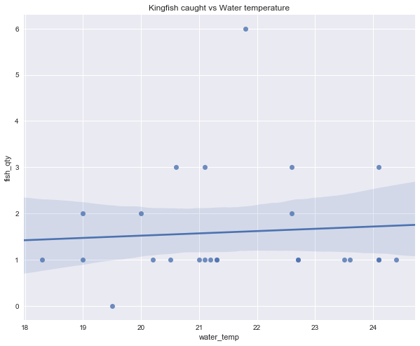

```python
plt.figure(figsize=(10,8))
sns.regplot(x='water_temp',y='fish_qty',data=kingy).set_title('Kingfish caught vs Water temperature');
```

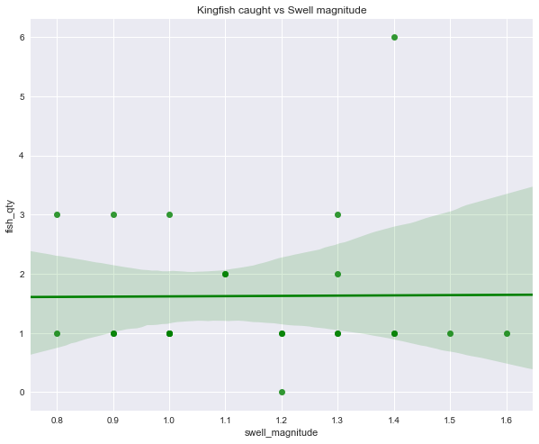

```python
plt.figure(figsize=(10,8))
sns.regplot(x='swell_magnitude',y='fish_qty',data=kingy, color='green').set_title('Kingfish caught vs Swell magnitude');
```

Our scatter plots with regression lines find no patterns so far. We can't really draw any conclusions from this since our dataset is so small.

One takeaway is that future data about a trip should always include fish targeted that weren't caught as part of the report. So if we are targeting snapper and catch none, there should be an entry for Snapper caught = 0. Sometimes trips are taken to just see what is around, so for those we can't write such an entry.

# Conclusion

In this notebook we cleaned and transformed out data from two journals and made them into one with the ideal schema moving forward.

We learned a little on Regular Expressions, Levenschtein distance and general functions that can be used for cleaning in Pandas.

## Limitations

- Historical weather conditions missing for some trips
- Safety rating and catch rating missing for most trips
- Hidden variables. We recognise that there will always be hidden variables in fishing.

## Future Work

- Update safety rating and catch rating. Will be a manual process.
- Find historic swell and weather data

# References

[Chair Nerd Blog - FuzzyWuzzy: Fuzzy String Matching in Python](https://chairnerd.seatgeek.com/fuzzywuzzy-fuzzy-string-matching-in-python/) 2018

[Regex101 - Testing Regular Expressions](https://regex101.com/) 2018

[Stack Overflow - Various Questions (Regular Expressions and Pandas)](https://stackoverflow.com/) 2018

[Gspread (Google Sheets API) official documentation](https://gspread.readthedocs.io/en/latest/) 2018

```python
# Chris Said's script to hide a bunch of stuff
HTML('''
''')
```

[python](https://jasonwillschiu.github.io/tag/python.html) [jupyter notebooks](https://jasonwillschiu.github.io/tag/jupyter-notebooks.html) [pandas](https://jasonwillschiu.github.io/tag/pandas.html) [google sheets](https://jasonwillschiu.github.io/tag/google-sheets.html) [api](https://jasonwillschiu.github.io/tag/api.html) [regex](https://jasonwillschiu.github.io/tag/regex.html)